# CFRM 502, Winter 2020

# Instructor: Bahman Angoshtari

# Solution to Homework 6

$\newcommand\Fc{\mathscr{F}}$ $\newcommand{\eps}{\varepsilon}$ $\newcommand{\Var}{\operatorname{Var}}$ $\newcommand\Cov{\operatorname{Cov}}$ $\newcommand\Corr{\operatorname{Corr}}$ $\newcommand{\sig}{\sigma}$ $\newcommand\Sig{\Sigma}$ $\newcommand{\al}{\alpha}$ $\newcommand{\gam}{\gamma}$ $\newcommand\Gam{\Gamma}$ $\newcommand\lam{\lambda}$ $\newcommand{\Del}{\Delta}$ $\newcommand\tht{\theta}$ $\newcommand\ph{\varphi}$ $\newcommand\om{\omega}$ $\newcommand\Om{\Omega}$ $\newcommand\rb{\bar{r}}$ $\newcommand{\Xb}{\bar{X}}$ $\newcommand{\Yb}{\bar{Y}}$ $\newcommand\Eb{\mathbb{E}}$ $\newcommand\Pb{\mathbb{P}}$ $\newcommand\Qb{\mathbb{Q}}$ $\newcommand\Rb{\mathbb{R}}$ $\newcommand\Zb{\mathbb{Z}}$ $\newcommand\Nb{\mathbb{N}}$ $\newcommand\Av{\textbf{A}}$ $\newcommand\Ev{\textbf{E}}$ $\newcommand\Dv{\textbf{D}}$ $\newcommand\Fv{\textbf{F}}$ $\newcommand\Gv{\textbf{G}}$ $\newcommand\Hv{\textbf{H}}$ $\newcommand\Kv{\textbf{K}}$ $\newcommand\Iv{\textbf{I}}$ $\newcommand\Pv{\textbf{P}}$ $\newcommand\Ov{\textbf{O}}$ $\newcommand\Sv{\textbf{S}}$ $\newcommand\Xv{\textbf{X}}$ $\newcommand\Yv{\textbf{Y}}$ $\newcommand\Zv{\textbf{Z}}$ $\newcommand\av{\mathbf{a}}$ $\newcommand\xv{\mathbf{x}}$ $\newcommand\yv{\mathbf{y}}$ $\newcommand\zv{\mathbf{z}}$ $\newcommand\Cv{\mathbf{C}}$ $\newcommand\mv{\mathbf{m}}$ $\newcommand\nv{\mathbf{n}}$ $\newcommand\pv{\mathbf{p}}$ $\newcommand\sv{\mathbf{s}}$ $\newcommand\wv{\mathbf{w}}$ $\newcommand\Wv{\textbf{W}}$ $\newcommand\alv{{\boldsymbol\al}}$ $\newcommand\betav{{\boldsymbol\beta}}$ $\newcommand\etav{{\boldsymbol\eta}}$ $\newcommand\epsv{{\boldsymbol\varepsilon}}$ $\newcommand\delv{{\boldsymbol\delta}}$ $\newcommand\Lamv{{\boldsymbol\Lambda}}$ $\newcommand\lamv{{\boldsymbol\lambda}}$ $\newcommand\muv{{\boldsymbol\mu}}$ $\newcommand\piv{{\boldsymbol\pi}}$ $\newcommand\Piv{{\boldsymbol\Pi}}$ $\newcommand\Gamv{{\boldsymbol\Gam}}$ $\newcommand\Phiv{{\boldsymbol\Phi}}$ $\newcommand\Sigv{{\boldsymbol\Sig}}$ $\newcommand\ah{\widehat{a}}$ $\newcommand\Pbh{\widehat{\Pb}}$ $\newcommand\phh{\widehat{\varphi}}$ $\newcommand\Ebh{\widehat{\Eb}}$ $\newcommand\Qh{\widehat{Q}}$ $\newcommand\Ih{\widehat{I}}$ $\newcommand\rh{\widehat{r}}$ $\newcommand\pih{\widehat{\pi}}$ $\newcommand\Pih{\widehat{\Pi}}$ $\newcommand\Sigvh{\widehat{\Sigv}}$ $\newcommand\Wh{\widehat{W}}$ $\newcommand\Fh{\widehat{F}}$ $\newcommand\Yh{\widehat{Y}}$ $\newcommand\Zh{\widehat{Z}}$ $\newcommand\Yvh{\widehat{\Yv}}$ $\newcommand\Ah{\widehat{\Ac}}$ $\newcommand\uh{\widehat{u}}$ $\newcommand\vh{\widehat{v}}$ $\newcommand\fh{\widehat{f}}$ $\newcommand\hh{\widehat{h}}$ $\newcommand\Bh{\widehat{B}}$ $\newcommand\Ovh{\widehat{\Ov}}$ $\newcommand\Xvh{\widehat{\Xv}}$ $\newcommand\rhoh{\widehat{\rho}}$ $\newcommand\nuh{\widehat{\nu}}$ $\newcommand\varphih{\widehat{\varphi}}$ $\newcommand\alh{\widehat{\al}}$ $\newcommand\thetah{\widehat{\theta}}$ $\newcommand\thth{\widehat{\theta}}$ $\newcommand\betah{\widehat{\beta}}$ $\newcommand\betavh{\widehat{\boldsymbol\beta}}$ $\newcommand\kaph{\widehat{\kappa}}$ $\newcommand\sigh{\widehat{\sigma}}$ $\newcommand\epsh{\widehat{\eps}}$ $\newcommand\epsvh{\widehat{\epsv}}$ $\newcommand\epst{\widetilde{\eps}}$ $\newcommand\muh{\widehat{\mu}}$ $\newcommand\dd{\mathrm{d}}$ $\newcommand\ee{\mathrm{e}}$ $\newcommand{\var}[1]{\text{Var} \left( #1 \right)}$

The following code sets up graphics in the Juypter notebook, and loads the necessary packages.

```r
# Setting parameters of the Jupyter notebook
sc = .75
options(repr.plot.width=16*sc,
        repr.plot.height=7*sc,
        repr.plot.pointsize = 13, # Text height in pt
        repr.plot.bg        = 'white',
        repr.plot.antialias = 'gray',
        #nice medium-res DPI
        repr.plot.res       = 300,
        #jpeg quality bumped from default
        repr.plot.quality   = 90,
        #vector font family
        repr.plot.family    = 'serif') # Vector font family. 'sans', 'serif', 'mono' or a specific one
library(quantmod)
library(tseries)
library(forecast)
library(rugarch)
library(foreach)
library(doParallel)
library(tictoc)
library(urca)
detectCores()
```

12

# 1.

(25 points) Consider the daily log return, in percentage, of Coca-Cola stock (KO) from January 3rd, 2007 to January 31st, 2018. You may obtain the data using `quantmod`, or load it from the text file "HW6-Q1.txt" that is posted with this homework using the following code.

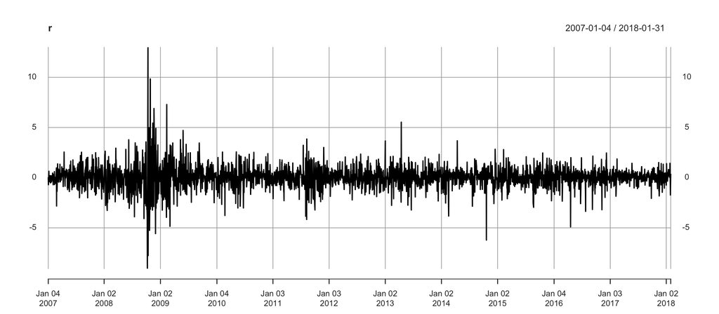

```r
dat=read.table("HW6-Q1.txt", header=TRUE, sep = ",")
KO=xts(dat[,2], order.by=as.Date(dat[, 1]));names(KO) = c("KO")
r = 100*diff(log(KO))[-1]
plot(r)
```

Let $\{r_t\}$ be the percentage daily log returns.

## (a)

(2 points) Are there any autocorrelation in $\{r_t\}$? Are there any ARCH effect in $\{r_t\}$? Why?

**Solution:** The sample ACF of $\{r_t\}$ and the corresponding Ljung-Box test indicates autocorrelation.

```
	Box-Ljung test

data:  r
X-squared = 38.76, df = 10, p-value = 2.796e-05
```

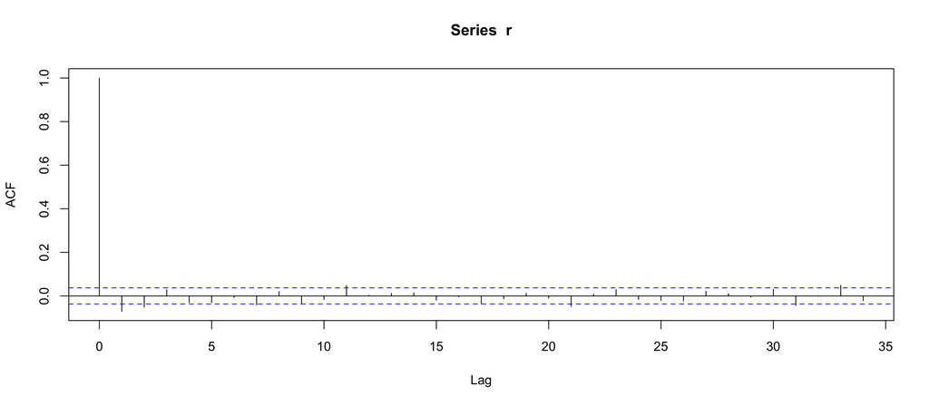

```r
acf(r)
Box.test(r, lag = 10, type = "Ljung-Box")
```

Similarly, sample ACF of $\{r_t^2\}$ and the corresponding Ljung-Box test indicates ARCH effect (non-constant volatility).

```
	Box-Ljung test

data:  r^2
X-squared = 1180.9, df = 10, p-value < 2.2e-16
```

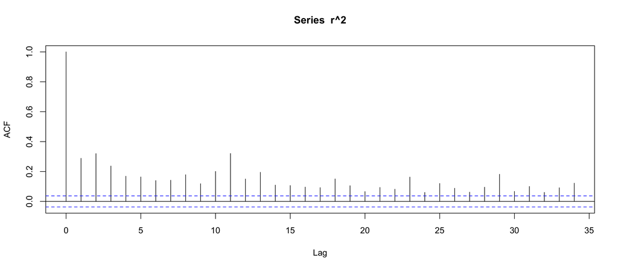

```r
acf(r^2)
Box.test(r^2, lag = 10, type = "Ljung-Box")
```

## (b)

(4 points) Build an ARMA+GARCH(1,1) model with normal residuals to $\{r_t\}$. Perform model checking and write down the fitted model.

**Solution:** We first find the ARMA specification. The `auto.arima` function suggests MA(1) model.

```r
fit=auto.arima(r, max.p = 20, max.q = 20, max.d = 2, ic="bic")
fit
```

```
Series: r
ARIMA(0,0,1) with zero mean

Coefficients:
          ma1
      -0.0761
s.e.   0.0198

sigma^2 estimated as 1.304:  log likelihood=-4327.32
AIC=8658.65   AICc=8658.65   BIC=8670.52
```

Next, we fit an MA(1)+GARCH(1,1) model. The fitted model is:

\begin{align*} \begin{cases} r_t - 0.057809 = (1-0.029818\,B) a_t;\\\\ a_t = \sig_t\eps_t,\quad\quad \eps_t\overset{i.i.d.}{\sim}N(0,1)\\\\ \sig_t^2 = 0.038856 + 0.100568\,a_{t-1}^2 + 0.866925\,\sig_{t-1}^2 \end{cases} \end{align*}

**Remark:** From the output below, the MA1 coefficient in the MA(1)+GARCH(1,1) model is insignificant. Thus, we can remove it. In other words, an ARMA(0,0)+GARCH(1,1) model is also a correct answer to this question.

```r
spec_b = ugarchspec(variance.model=list(model="sGARCH", garchOrder=c(1,1)),
                  mean.model=list(armaOrder=c(0,1)))
fit_b = ugarchfit(data=r, spec=spec_b)
show(fit_b)
```

```
*---------------------------------*
*          GARCH Model Fit        *
*---------------------------------*

Conditional Variance Dynamics
-----------------------------------
GARCH Model	: sGARCH(1,1)
Mean Model	: ARFIMA(0,0,1)
Distribution	: norm

Optimal Parameters
------------------------------------
        Estimate  Std. Error  t value Pr(>|t|)
mu      0.057809    0.016267   3.5537 0.000380
ma1    -0.029818    0.021336  -1.3976 0.162246
omega   0.038856    0.009475   4.1007 0.000041
alpha1  0.100568    0.015494   6.4906 0.000000
beta1   0.866925    0.020715  41.8493 0.000000

Robust Standard Errors:
        Estimate  Std. Error  t value Pr(>|t|)
mu      0.057809    0.016060   3.5997 0.000319
ma1    -0.029818    0.022733  -1.3117 0.189637
omega   0.038856    0.017054   2.2784 0.022703
alpha1  0.100568    0.030871   3.2577 0.001123
beta1   0.866925    0.039763  21.8021 0.000000

LogLikelihood : -3897.284

Information Criteria
------------------------------------

Akaike       2.7983
Bayes        2.8090
Shibata      2.7983
Hannan-Quinn 2.8022

Weighted Ljung-Box Test on Standardized Residuals
------------------------------------
                        statistic p-value
```

[output cut: 39 more lines]

```
Negative Sign Bias  1.9904 0.04665  **
Positive Sign Bias  0.3816 0.70281
Joint Effect        4.8489 0.18321


Adjusted Pearson Goodness-of-Fit Test:
------------------------------------
  group statistic p-value(g-1)
1    20     107.9    1.904e-14
2    30     121.3    2.986e-13
3    40     126.3    3.853e-11
4    50     153.9    9.265e-13


Elapsed time : 0.2204001
```

The model checking indicates that the residuals are weak WN since the sample ACF plot and the corresponding Ljung-Box test don't show any autocorrelation. The residual$^2$ are also not autocorrelated, thus, there is no ARCH effect. The residuals are not normal as the QQ plot indicates.

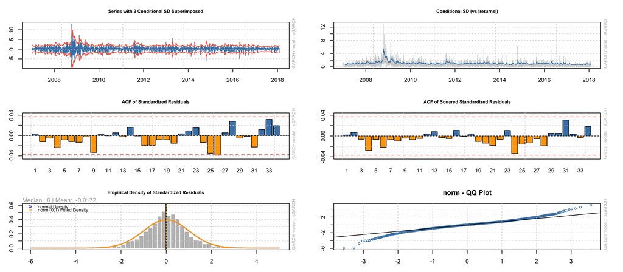

```r
par(mfrow=c(3,2));par(mar=c(3,3,3,3))
plot(fit_b,which=1)
plot(fit_b,which=3)
plot(fit_b,which=10)
plot(fit_b,which=11)
plot(fit_b,which=8)
plot(fit_b,which=9)
```

## (c)

(4 points) Build an ARMA+GARCH(1,1) model with Student-t residuals to $\{r_t\}$. Perform model checking and write down the fitted model.

**Solution:** The fitted model is:

\begin{align*} \begin{cases} r_t - 0.063812 = (1-0.020204\,B) a_t;\\\\ a_t = \sig_t\eps_t,\quad\quad \eps_t\overset{i.i.d.}{\sim}t_{4.809596}\\\\ \sig_t^2 = 0.018982 + 0.076673\,a_{t-1}^2 + 0.911544\,\sig_{t-1}^2 \end{cases} \end{align*}

```r
spec_c = ugarchspec(variance.model=list(model="sGARCH", garchOrder=c(1,1)),
                    mean.model=list(armaOrder=c(0,1)),
                    distribution.model="std")
fit_c = ugarchfit(data=r, spec=spec_c)
show(fit_c)
```

```
*---------------------------------*
*          GARCH Model Fit        *
*---------------------------------*

Conditional Variance Dynamics
-----------------------------------
GARCH Model	: sGARCH(1,1)
Mean Model	: ARFIMA(0,0,1)
Distribution	: std

Optimal Parameters
------------------------------------
        Estimate  Std. Error  t value Pr(>|t|)
mu      0.063812    0.014862   4.2937 0.000018
ma1    -0.020204    0.019051  -1.0605 0.288902
omega   0.018982    0.008510   2.2304 0.025718
alpha1  0.076673    0.018552   4.1327 0.000036
beta1   0.911544    0.022674  40.2026 0.000000
shape   4.809596    0.461519  10.4212 0.000000

Robust Standard Errors:
        Estimate  Std. Error  t value Pr(>|t|)
mu      0.063812    0.014216   4.4886 0.000007
ma1    -0.020204    0.019379  -1.0426 0.297130
omega   0.018982    0.015087   1.2582 0.208334
alpha1  0.076673    0.037240   2.0589 0.039504
beta1   0.911544    0.045442  20.0597 0.000000
shape   4.809596    0.432180  11.1287 0.000000

LogLikelihood : -3789.241

Information Criteria
------------------------------------

Akaike       2.7216
Bayes        2.7343
Shibata      2.7216
Hannan-Quinn 2.7262

Weighted Ljung-Box Test on Standardized Residuals
```

[output cut: 42 more lines]

```
Negative Sign Bias 2.36496 0.01810  **
Positive Sign Bias 0.08323 0.93367
Joint Effect       6.36679 0.09507   *


Adjusted Pearson Goodness-of-Fit Test:
------------------------------------
  group statistic p-value(g-1)
1    20     12.91       0.8429
2    30     27.33       0.5538
3    40     30.15       0.8445
4    50     43.14       0.7084


Elapsed time : 0.354701
```

The mean and volatility equation are adequate. The standardized residuals have t distribution according to the QQ plot.

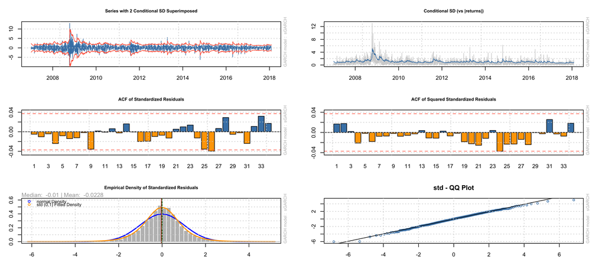

```r
par(mfrow=c(3,2));par(mar=c(3,3,3,3))
plot(fit_c,which=1)
plot(fit_c,which=3)
plot(fit_c,which=10)
plot(fit_c,which=11)
plot(fit_c,which=8)
plot(fit_c,which=9)
```

## (d)

(5 points) Build an ARMA+GARCH(1,1) model with skew-Student-t residuals to $\{r_t\}$. Perform model checking and write down the fitted model. Based on the model, are the returns of KO stock skewed?

**Solution:** We try the skew-t distributions ("sstd" in ugarch package). Using skew normal ("snorm") or skew generalized error ("sged") is also acceptable. The fitted model is:

\begin{align*} \begin{cases} r_t - 0.052636 = (1-0.021572\,B) a_t;\\\\ a_t = \sig_t\eps_t,\quad\quad \eps_t\overset{i.i.d.}{\sim}\text{skew-}t_{\{\text{df}=4.825236, \text{ skew=0.958290}\}}\\\\ \sig_t^2 = 0.019553 + 0.077582\,a_{t-1}^2 + 0.910054\,\sig_{t-1}^2 \end{cases} \end{align*}

```r
spec_d = ugarchspec(variance.model=list(model="sGARCH", garchOrder=c(1,1)),
                  mean.model=list(armaOrder=c(0,1)),
                 distribution.model="sstd")
fit_d = ugarchfit(data=r, spec=spec_d)
show(fit_d)
```

```
*---------------------------------*
*          GARCH Model Fit        *
*---------------------------------*

Conditional Variance Dynamics
-----------------------------------
GARCH Model	: sGARCH(1,1)
Mean Model	: ARFIMA(0,0,1)
Distribution	: sstd

Optimal Parameters
------------------------------------
        Estimate  Std. Error  t value Pr(>|t|)
mu      0.052636    0.016288   3.2315 0.001231
ma1    -0.021572    0.019076  -1.1309 0.258115
omega   0.019553    0.008490   2.3030 0.021280
alpha1  0.077582    0.018298   4.2400 0.000022
beta1   0.910054    0.022381  40.6617 0.000000
skew    0.958290    0.024516  39.0878 0.000000
shape   4.825236    0.464491  10.3882 0.000000

Robust Standard Errors:
        Estimate  Std. Error  t value Pr(>|t|)
mu      0.052636    0.015623   3.3691 0.000754
ma1    -0.021572    0.019461  -1.1085 0.267660
omega   0.019553    0.014539   1.3449 0.178656
alpha1  0.077582    0.035398   2.1917 0.028400
beta1   0.910054    0.043307  21.0142 0.000000
skew    0.958290    0.024158  39.6672 0.000000
shape   4.825236    0.434593  11.1029 0.000000

LogLikelihood : -3787.856

Information Criteria
------------------------------------

Akaike       2.7213
Bayes        2.7362
Shibata      2.7213
Hannan-Quinn 2.7267
```

[output cut: 45 more lines]

```
Negative Sign Bias  2.4610 0.01391  **
Positive Sign Bias  0.1942 0.84600
Joint Effect        6.7011 0.08206   *


Adjusted Pearson Goodness-of-Fit Test:
------------------------------------
  group statistic p-value(g-1)
1    20     11.72       0.8971
2    30     21.46       0.8419
3    40     27.13       0.9241
4    50     51.25       0.3856


Elapsed time : 0.491632
```

The mean and volatility equation are adequate. The standardized residuals have t distribution according to the QQ plot.

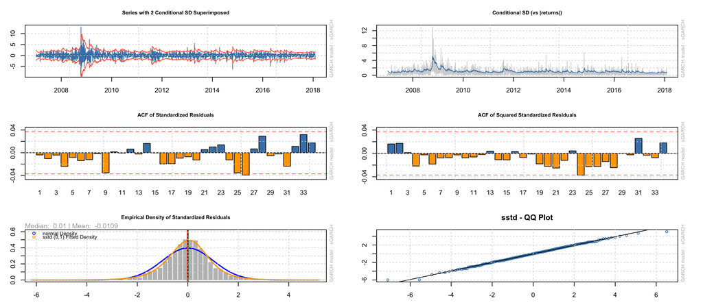

```r
par(mfrow=c(3,2));par(mar=c(3,3,3,3))
plot(fit_d,which=1)
plot(fit_d,which=3)
plot(fit_d,which=10)
plot(fit_d,which=11)
plot(fit_d,which=8)
plot(fit_d,which=9)
```

Finally, since the skewness parameter of the skew-t distribution is significant (p-value is 0), there is evidence of skewness in the returns.

(5 points) Does the return of KO stock has risk premium? You should answer based on an appropriate statistical model. Write down the model and perform model checking.

**Solution:** We fit a MA(1)+GARCH(1,1)-M and test if the risk-premium coefficient is zero or not. The fitted model is:

\begin{align*} \begin{cases} r_t - 0.060656 - 0.003761 \sig_t^2 = (1-0.020278\,B) a_t;\\\\ a_t = \sig_t\eps_t,\quad\quad \eps_t\overset{i.i.d.}{\sim}t_{\{\text{df}=4.811817\}}\\\\ \sig_t^2 = 0.019157 + 0.077120\,a_{t-1}^2 + 0.910981\,\sig_{t-1}^2 \end{cases} \end{align*}

```r
spec_e = ugarchspec(variance.model=list(model="sGARCH", garchOrder=c(1,1)),
                  mean.model=list(armaOrder=c(0,1), archm=TRUE, archpow=2),
                 distribution.model="std")
fit_e = ugarchfit(data=r, spec=spec_e)
show(fit_e)
```

```
*---------------------------------*
*          GARCH Model Fit        *
*---------------------------------*

Conditional Variance Dynamics
-----------------------------------
GARCH Model	: sGARCH(1,1)
Mean Model	: ARFIMA(0,0,1)
Distribution	: std

Optimal Parameters
------------------------------------
        Estimate  Std. Error  t value Pr(>|t|)
mu      0.060656    0.025026  2.42368 0.015364
ma1    -0.020278    0.019066 -1.06359 0.287513
archm   0.003761    0.024001  0.15669 0.875491
omega   0.019157    0.008141  2.35312 0.018617
alpha1  0.077120    0.017663  4.36631 0.000013
beta1   0.910981    0.021393 42.58384 0.000000
shape   4.811817    0.461973 10.41580 0.000000

Robust Standard Errors:
        Estimate  Std. Error  t value Pr(>|t|)
mu      0.060656    0.024485  2.47728 0.013239
ma1    -0.020278    0.019433 -1.04349 0.296723
archm   0.003761    0.022698  0.16568 0.868407
omega   0.019157    0.013428  1.42673 0.153658
alpha1  0.077120    0.033073  2.33184 0.019709
beta1   0.910981    0.039995 22.77764 0.000000
shape   4.811817    0.431483 11.15180 0.000000

LogLikelihood : -3789.229

Information Criteria
------------------------------------

Akaike       2.7223
Bayes        2.7372
Shibata      2.7223
Hannan-Quinn 2.7277
```

[output cut: 45 more lines]

```
Negative Sign Bias 2.34101 0.0193  **
Positive Sign Bias 0.06855 0.9454
Joint Effect       6.22947 0.1010


Adjusted Pearson Goodness-of-Fit Test:
------------------------------------
  group statistic p-value(g-1)
1    20     14.84       0.7329
2    30     27.40       0.5503
3    40     32.84       0.7457
4    50     47.59       0.5304


Elapsed time : 0.7909131
```

The mean and volatility equation are adequate. The standardized residuals have t distribution according to the QQ plot.

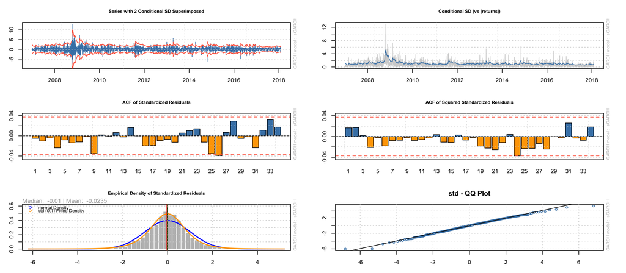

```r
par(mfrow=c(3,2));par(mar=c(3,3,3,3))
plot(fit_e,which=1)
plot(fit_e,which=3)
plot(fit_e,which=10)
plot(fit_e,which=11)
plot(fit_e,which=8)
plot(fit_e,which=9)
```

Finally, since the risk-premium parameter "archm" is **insignificant** (p-value is 0.875491), there is no evidence of risk premium.

## (f)

(5 points) Does the return of KO stock show leverage effect? You should answer based on an appropriate statistical model. Write down the model and perform model checking.

**Solution:** We fit an MA(1)+APARCH(1,1) model and test if the leverage coefficient is zero or not.

**Remark:** We could also use a EGARCH or a GJR-GARCH (a.k.a TGARCH) volatility model. For EGARCH the leverage parameter is "alpha1". For GJR-GARCH, the leverage parameter is "gamma1" (as in the APARCH model).

The fitted model is:

```r
spec_f = ugarchspec(variance.model=list(model="apARCH", garchOrder=c(1,1)),
                  mean.model=list(armaOrder=c(0,1)),
                  distribution.model="std")
fit_f = ugarchfit(data=r, spec=spec_f)
show(fit_f)
```

```
*---------------------------------*
*          GARCH Model Fit        *
*---------------------------------*

Conditional Variance Dynamics
-----------------------------------
GARCH Model	: apARCH(1,1)
Mean Model	: ARFIMA(0,0,1)
Distribution	: std

Optimal Parameters
------------------------------------
        Estimate  Std. Error  t value Pr(>|t|)
mu      0.053768    0.011145   4.8242 0.000001
ma1    -0.024900    0.009452  -2.6342 0.008433
omega   0.025336    0.007406   3.4210 0.000624
alpha1  0.090277    0.014391   6.2732 0.000000
beta1   0.908478    0.016093  56.4523 0.000000
gamma1  0.379387    0.103251   3.6744 0.000238
delta   0.719271    0.158649   4.5337 0.000006
shape   5.284521    0.543219   9.7282 0.000000

Robust Standard Errors:
        Estimate  Std. Error  t value Pr(>|t|)
mu      0.053768    0.008806   6.1057 0.000000
ma1    -0.024900    0.005481  -4.5429 0.000006
omega   0.025336    0.009228   2.7457 0.006038
alpha1  0.090277    0.020859   4.3280 0.000015
beta1   0.908478    0.022546  40.2941 0.000000
gamma1  0.379387    0.098920   3.8353 0.000125
delta   0.719271    0.156895   4.5844 0.000005
shape   5.284521    0.470346  11.2354 0.000000

LogLikelihood : -3766.034

Information Criteria
------------------------------------

Akaike       2.7064
Bayes        2.7234
```

[output cut: 48 more lines]

```
Negative Sign Bias  1.4370 0.1508
Positive Sign Bias  0.2060 0.8368
Joint Effect        2.1197 0.5479


Adjusted Pearson Goodness-of-Fit Test:
------------------------------------
  group statistic p-value(g-1)
1    20     17.10       0.5829
2    30     28.47       0.4928
3    40     39.21       0.4604
4    50     44.76       0.6457


Elapsed time : 1.264787
```

The mean and volatility equation are adequate. The standardized residuals have t distribution according to the QQ plot.

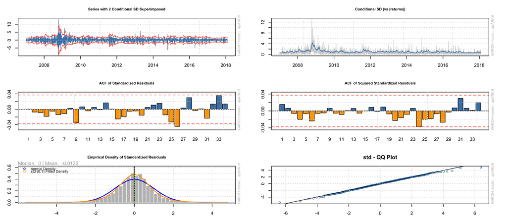

```r
par(mfrow=c(3,2));par(mar=c(3,3,3,3))
plot(fit_f,which=1)
plot(fit_f,which=3)
plot(fit_f,which=10)
plot(fit_f,which=11)
plot(fit_f,which=8)
plot(fit_f,which=9)
```

Finally, the leverage parameter "gamma1" is **significant** (p-value is 0.000238). So, there is evidence of leverage effect.

# 2

## (a)

(6 points) For the data in Question 4 of Homework 5, build an ARIMAX+GARCH model for $y$ with $x$ as the predictor. Write down the fitted model. Perform Model checking. Resolve any issue that you encounter by extending the model. You only need to report your final model and show that it passes model checking.

**Solution:** Let us first load the data.

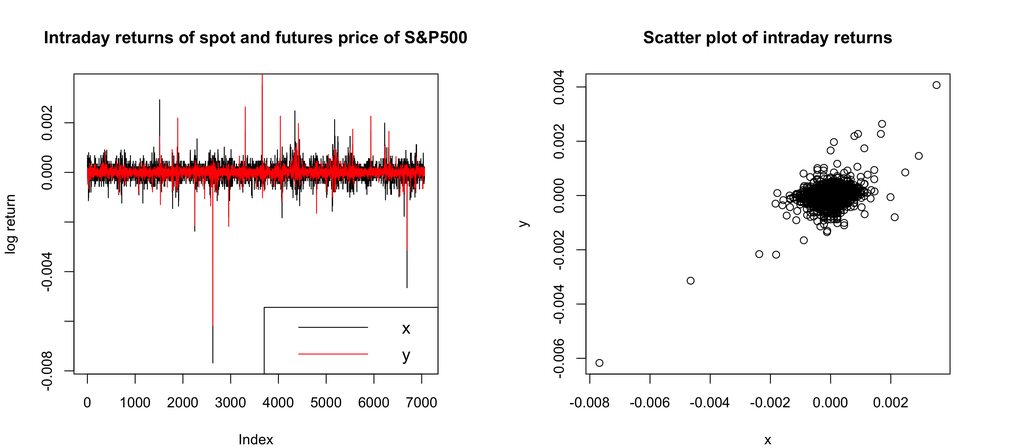

```r
dat = read.table("HW5-Q4.txt",header=T)
s = dat[,1];f = dat[,2]
y = na.omit(diff(f))
x = na.omit(diff(s))
par(mfrow=c(1,2));par(mar=c(4,4,4,4))
plot(x, type="l", ylab="log return",
     main="Intraday returns of spot and futures price of S&P500")
lines(y, type="l",col="red")
legend("bottomright",c("x","y"),cex=1.2, y.intersp=2,
       box.lty=1,lty=c(1,1), col=c(1,"red"))
plot(x,y,xlab="x", ylab="y", main="Scatter plot of intraday returns")
```

```
Series: y
Regression with ARIMA(1,0,1) errors

Coefficients:
         ar1      ma1    xreg
      0.6557  -0.5549  0.2251
s.e.  0.0614   0.0676  0.0069

sigma^2 estimated as 3.344e-08:  log likelihood=50747.43
AIC=-101486.9   AICc=-101486.9   BIC=-101459.4
```

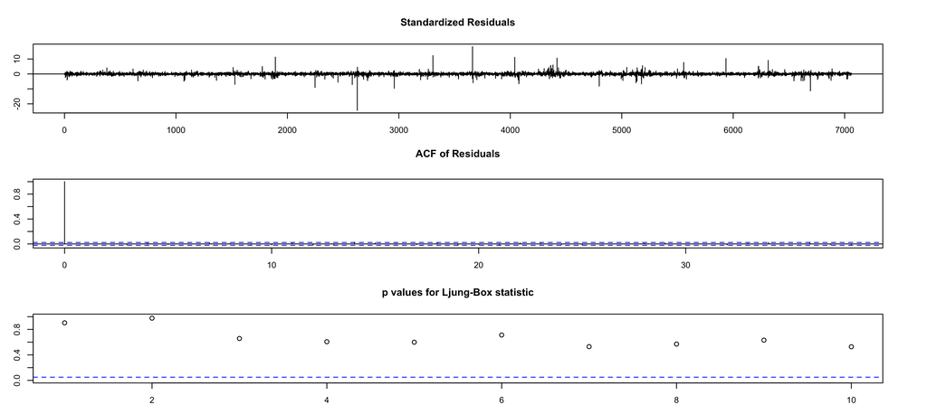

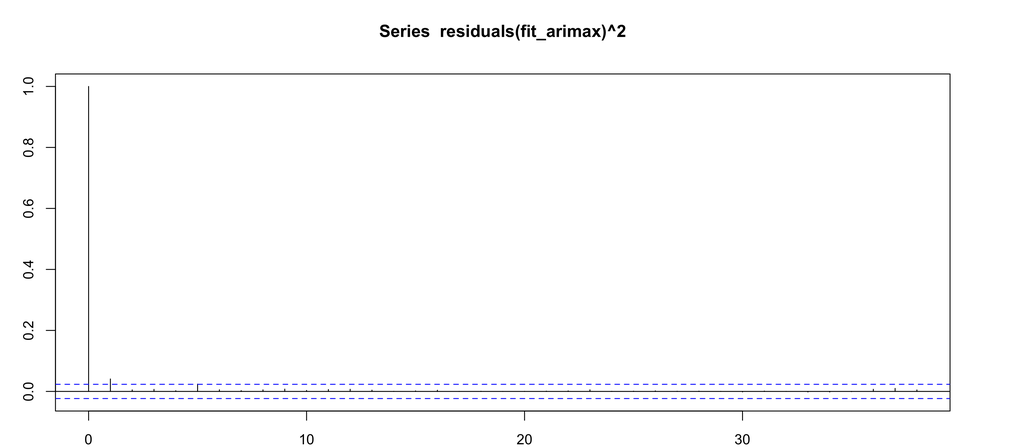

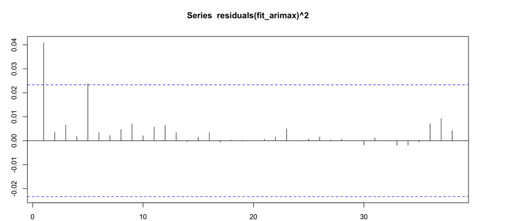

```r
fit_arimax = auto.arima(y, max.p=20, xreg = x, max.q = 20, max.d=3, ic="bic")
fit_arimax
par(mar=c(2,3,4,4))
tsdiag(fit_arimax)
acf(residuals(fit_arimax)^2)
pacf(residuals(fit_arimax)^2)
```

The fitted model is:

\begin{align*} \begin{cases} (1-0.6557 B) (y_t - 0.2251\,x_t) = (1-0.5549 B) \eps_t\\ \eps_t \sim \text{ weak WN}(0, \sig_\eps^2=3.344\,10^{-8}) \end{cases} \end{align*}

The mean specification is adequate. However, the residuals$^2$ are autocorrelated. **Note, also, that the reported maximum log-likelihood is 50747.43.**

To remedy the ARCH effect in the residual, we fit a ARMAX(1,0,1)+GARCH(1,1) to $y$, with $x$ as the predictor.

**Remark:** Using ARCH(1) is also acceptable, as indicated by the sample PACF of residuals$^2$

The fitted model is:

\begin{align}\tag{$\star$} \begin{cases} (1-0.655546 B) (y_t - 0.430045\,x_t) = (1-0.555176 B) a_t\\ a_t = \sig_t\eps_t,\quad \eps_t \overset{i.i.d.}{\sim}N(0,1)\\ \sig_t^2 = 0.050392\, a_{t-1}^2 + 0.900118\,\sig_{t-1}^2 \end{cases} \end{align}

We make the following observation:

So, this model is not a good fit. Also, note that the ARMAX(1,0,1) is a special case of ARMAX(1,0,1)+GARCH(1,1). So, the former cannot achieve a better log-likelihood value. These observations indicate that the optimization model have not found the true maximum likelihood, and is reporting a local maximum instead of the global maximum.

```
*---------------------------------*
*          GARCH Model Fit        *
*---------------------------------*

Conditional Variance Dynamics
-----------------------------------
GARCH Model	: sGARCH(1,1)
Mean Model	: ARFIMA(1,0,1)
Distribution	: norm

Optimal Parameters
------------------------------------
        Estimate  Std. Error    t value Pr(>|t|)
ar1     0.655546    0.116871   5.609145 0.000000
ma1    -0.555176    0.145403  -3.818178 0.000134
mxreg1  0.430045    0.004925  87.325805 0.000000
omega   0.000000    0.000000   0.000994 0.999207
alpha1  0.050392    0.000672  74.942320 0.000000
beta1   0.900118    0.002401 374.875615 0.000000

Robust Standard Errors:
        Estimate  Std. Error   t value Pr(>|t|)
ar1     0.655546   57.476916  0.011405  0.99090
ma1    -0.555176   69.413673 -0.007998  0.99362
mxreg1  0.430045   10.894644  0.039473  0.96851
omega   0.000000    0.000453  0.000000  1.00000
alpha1  0.050392    4.265831  0.011813  0.99057
beta1   0.900118   10.298471  0.087403  0.93035

LogLikelihood : 48751.45

Information Criteria
------------------------------------

Akaike       -13.809
Bayes        -13.803
Shibata      -13.809
Hannan-Quinn -13.807

Weighted Ljung-Box Test on Standardized Residuals
```

[output cut: 42 more lines]

```
Negative Sign Bias  0.7923 0.4282
Positive Sign Bias  0.5319 0.5948
Joint Effect        1.0018 0.8008


Adjusted Pearson Goodness-of-Fit Test:
------------------------------------
  group statistic p-value(g-1)
1    20     952.6   7.051e-190
2    30    1225.7   1.295e-239
3    40    1405.0   1.359e-269
4    50    1545.7   1.352e-291


Elapsed time : 0.335726
```

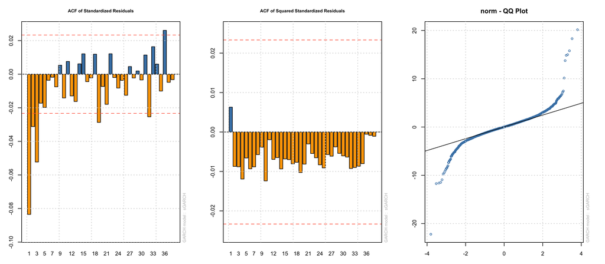

```r
spec_3a_1 = ugarchspec(variance.model=list(model="sGARCH", garchOrder=c(1,1)),,
                     mean.model=list(armaOrder=c(1,1), include.mean=F,
                                     external.regressors=as.matrix(x)))
fit_3a_1 = ugarchfit(data=y, spec=spec_3a_1)
show(fit_3a_1)
par(mfrow=c(1,3));par(mar=c(3,3,3,3))
plot(fit_3a_1,which=10)
plot(fit_3a_1,which=11)
plot(fit_3a_1,which=9)
```

To confirm our suspicions that `ugarchfit` didn't find the global maximum of the likelihood function, let us set the coefficient of $x_t$ to the value found by the ARIMAX model. The fitted model is

\begin{align}\tag{$\star\star$} \begin{cases} (1-0.661659 B) (y_t - 0.224900 \,x_t) = (1-0.553734\, B) a_t\\ a_t = \sig_t\eps_t,\quad \eps_t \overset{i.i.d.}{\sim}N(0,1)\\ \sig_t^2 = 0.059011\, a_{t-1}^2 + 0.903630\,\sig_{t-1}^2 \end{cases} \end{align}

Model checking reveals that $(\star\star)$ is a better fit, although the standard residuals are not normal despite the normality assumption.

```
*---------------------------------*
*          GARCH Model Fit        *
*---------------------------------*

Conditional Variance Dynamics
-----------------------------------
GARCH Model	: sGARCH(1,1)
Mean Model	: ARFIMA(1,0,1)
Distribution	: norm

Optimal Parameters
------------------------------------
        Estimate  Std. Error    t value Pr(>|t|)
mu     -0.000015    0.000002  -7.016877  0.00000
ar1     0.661659    0.077881   8.495768  0.00000
ma1    -0.553734    0.079953  -6.925762  0.00000
mxreg1  0.224900          NA         NA       NA
omega   0.000000    0.000000   0.017514  0.98603
alpha1  0.059011    0.004552  12.962992  0.00000
beta1   0.903630    0.003595 251.329687  0.00000

Robust Standard Errors:
        Estimate  Std. Error   t value Pr(>|t|)
mu     -0.000015    0.002694 -0.005491  0.99562
ar1     0.661659    4.523571  0.146269  0.88371
ma1    -0.553734    0.294012 -1.883372  0.05965
mxreg1  0.224900          NA        NA       NA
omega   0.000000    0.001175  0.000001  1.00000
alpha1  0.059011   15.451198  0.003819  0.99695
beta1   0.903630    4.475006  0.201928  0.83997

LogLikelihood : 51136.28

Information Criteria
------------------------------------

Akaike       -14.484
Bayes        -14.479
Shibata      -14.485
Hannan-Quinn -14.482
```

[output cut: 44 more lines]

```
Negative Sign Bias  2.4159 0.01572  **
Positive Sign Bias  0.3437 0.73108
Joint Effect        7.0473 0.07041   *


Adjusted Pearson Goodness-of-Fit Test:
------------------------------------
  group statistic p-value(g-1)
1    20     958.4   3.925e-191
2    30     983.6   2.487e-188
3    40     998.4   4.833e-184
4    50    1010.9   8.734e-180


Elapsed time : 0.3552141
```

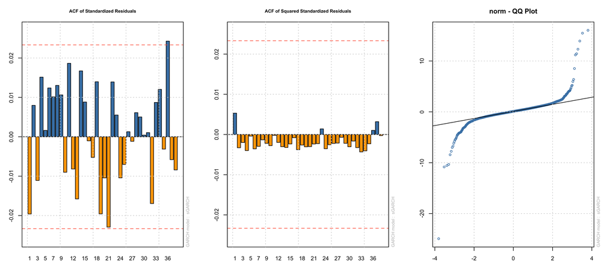

```r
spec_3a_2 = ugarchspec(variance.model=list(model="sGARCH", garchOrder=c(1,1)),
                     mean.model=list(armaOrder=c(1,1), include.mean=T,
                                     external.regressors=as.matrix(x)),
                     fixed.pars = list(mxreg1=0.2249))
fit_3a_2 = ugarchfit(data=y, spec=spec_3a_2)
show(fit_3a_2)
par(mfrow=c(1,3));par(mar=c(3,3,3,3))
plot(fit_3a_2,which=10)
plot(fit_3a_2,which=11)
plot(fit_3a_2,which=9)
```

A good fit, can be found as follows. First we fit the unrestricted ARMAX(1,0,1)+GARCH(1,1) again, but this time we change the optimization solver by passing the `solver = 'nloptr'` to `ugarchfit`.

```
*---------------------------------*
*          GARCH Model Fit        *
*---------------------------------*

Conditional Variance Dynamics
-----------------------------------
GARCH Model	: sGARCH(1,1)
Mean Model	: ARFIMA(1,0,1)
Distribution	: norm

Optimal Parameters
------------------------------------
        Estimate  Std. Error    t value Pr(>|t|)
mu      0.000001    0.000003   0.209106  0.83437
ar1     0.841858    0.041939  20.073564  0.00000
ma1    -0.776272    0.049038 -15.829872  0.00000
mxreg1  0.233482    0.007294  32.010400  0.00000
omega   0.000000    0.000000   0.010483  0.99164
alpha1  0.100000    0.008763  11.412206  0.00000
beta1   0.900000    0.005599 160.729482  0.00000

Robust Standard Errors:
        Estimate  Std. Error   t value Pr(>|t|)
mu      0.000001    0.000832  0.000652  0.99948
ar1     0.841858    3.086570  0.272749  0.78505
ma1    -0.776272    4.286781 -0.181085  0.85630
mxreg1  0.233482    0.588599  0.396673  0.69161
omega   0.000000    0.000979  0.000001  1.00000
alpha1  0.100000   45.046334  0.002220  0.99823
beta1   0.900000   33.315835  0.027014  0.97845

LogLikelihood : 51202.57

Information Criteria
------------------------------------

Akaike       -14.503
Bayes        -14.496
Shibata      -14.503
Hannan-Quinn -14.501
```

[output cut: 45 more lines]

```
Negative Sign Bias  1.2887 0.1975
Positive Sign Bias  0.5736 0.5663
Joint Effect        2.8753 0.4112


Adjusted Pearson Goodness-of-Fit Test:
------------------------------------
  group statistic p-value(g-1)
1    20     876.4   1.193e-173
2    30     898.5   2.230e-170
3    40     906.1   8.971e-165
4    50     917.5   1.685e-160


Elapsed time : 2.088545
```

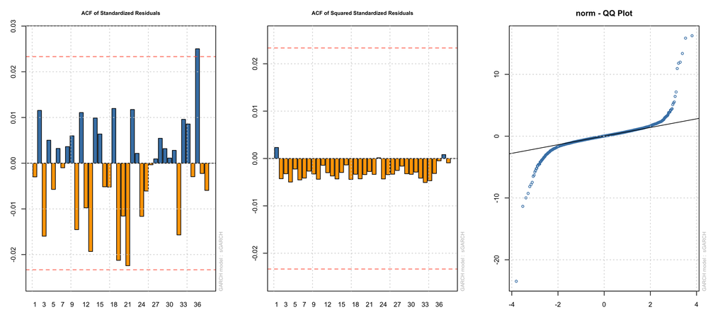

```r
spec_3a = ugarchspec(variance.model=list(model="sGARCH", garchOrder=c(1,1)),
                     mean.model=list(armaOrder=c(1,1), include.mean=T,
                                     external.regressors=as.matrix(x)))
fit_3a = ugarchfit(data=y, spec=spec_3a, solver = 'nloptr')
show(fit_3a)
par(mfrow=c(1,3));par(mar=c(3,3,3,3))
plot(fit_3a,which=10)
plot(fit_3a,which=11)
plot(fit_3a,which=9)
```

- Note that the mean and volatility equations are adequate. To deal with the non-normality of the residuals, we fit a ARMAX(1,0,1)+GARCH(1,1) model with student-t errors. We change the solver by `solver = 'nloptr'` and fix the value of $x_t$ coefficient to the value estimated by the ARMAX(1,0,1)+GARCH(1,1) model with Gaussian errors. The fitted model is

\begin{align}\tag{$\star\star\star$} \begin{cases} (1-0.759536 B) (y_t - 0.000005 - 0.233482 \,x_t) = (1-0.704653\, B) a_t\\\\ \displaystyle a_t = \sig_t\eps_t,\quad \eps_t \overset{i.i.d.}{\sim}t_{\text{df}=4.116171}\\\\ \sig_t^2 = 0.072724\, a_{t-1}^2 + 0.914296\,\sig_{t-1}^2 \end{cases} \end{align}

```
*---------------------------------*
*          GARCH Model Fit        *
*---------------------------------*

Conditional Variance Dynamics
-----------------------------------
GARCH Model	: sGARCH(1,1)
Mean Model	: ARFIMA(1,0,1)
Distribution	: std

Optimal Parameters
------------------------------------
        Estimate  Std. Error    t value Pr(>|t|)
mu      0.000005    0.000002   2.871688 0.004083
ar1     0.759536    0.048089  15.794488 0.000000
ma1    -0.704653    0.052774 -13.352297 0.000000
mxreg1  0.233482          NA         NA       NA
omega   0.000000    0.000000   0.009317 0.992566
alpha1  0.072724    0.005946  12.230441 0.000000
beta1   0.914296    0.004746 192.640420 0.000000
shape   4.116171    0.338476  12.160909 0.000000

Robust Standard Errors:
        Estimate  Std. Error   t value Pr(>|t|)
mu      0.000005    0.000011  0.434913  0.66363
ar1     0.759536    1.438583  0.527975  0.59752
ma1    -0.704653    1.706905 -0.412825  0.67973
mxreg1  0.233482          NA        NA       NA
omega   0.000000    0.000056  0.000009  0.99999
alpha1  0.072724    6.124771  0.011874  0.99053
beta1   0.914296    2.852040  0.320576  0.74853
shape   4.116171   83.493682  0.049299  0.96068

LogLikelihood : 52772.14

Information Criteria
------------------------------------

Akaike       -14.948
Bayes        -14.941
```

[output cut: 47 more lines]

```
Negative Sign Bias  1.4410 0.1496
Positive Sign Bias  0.4045 0.6859
Joint Effect        3.1218 0.3732


Adjusted Pearson Goodness-of-Fit Test:
------------------------------------
  group statistic p-value(g-1)
1    20     36.08     0.010305
2    30     51.03     0.006982
3    40     51.18     0.091549
4    50     70.31     0.024588


Elapsed time : 6.689173
```

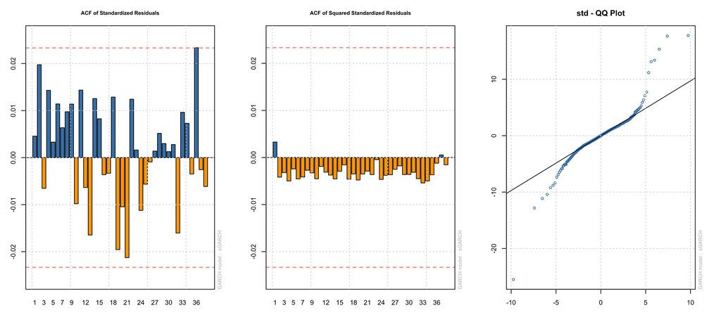

```r
spec_3a = ugarchspec(variance.model=list(model="sGARCH", garchOrder=c(1,1)),
                     mean.model=list(armaOrder=c(1,1), include.mean=T,
                                     external.regressors=as.matrix(x)),
                     distribution.model="std",
                     fixed.pars = list(mxreg1=0.233482))
fit_3a = ugarchfit(data=y, spec=spec_3a, solver = 'nloptr')
show(fit_3a)
par(mfrow=c(1,3));par(mar=c(3,3,3,3))
plot(fit_3a,which=10)
plot(fit_3a,which=11)
plot(fit_3a,which=9)
```

**Remark:** 2 points if only Model $(\star)$ is provided. 5 points if model $(\star\star)$ is provided. 6 points if model $(\star\star\star)$ is provided.

## (b)

(2 points) In the ARIMAX model in part (a), do negative shocks to the error term affect vol more than positive shocks? Your answer should be based on a statistical model. Write down the model and perform model checking.

**Solution:** We fit an ARMAX(1,1) + APARCH(1,1) model and check if the model is adequate. It is important to use the `solver = 'nloptr'` argument, otherwise `ugarchfit` will not find the global maximum of the likelihood function.

The fitted ARMAX(1,1) + APARCH(1,1) with normal error is given in the following output. The mean and volatility model is adequate. The normal probability plot of the standardized residuals are indicate non-normality. We need to address the non-normality before draw conclusion from the model.

```
*---------------------------------*
*          GARCH Model Fit        *
*---------------------------------*

Conditional Variance Dynamics
-----------------------------------
GARCH Model	: apARCH(1,1)
Mean Model	: ARFIMA(1,0,1)
Distribution	: norm

Optimal Parameters
------------------------------------
        Estimate  Std. Error    t value Pr(>|t|)
mu      0.000002    0.000003   0.708430 0.478678
ar1     0.857964    0.033756  25.416608 0.000000
ma1    -0.790414    0.039547 -19.986459 0.000000
mxreg1  0.231854    0.007750  29.918196 0.000000
omega   0.000000    0.000000   0.008618 0.993124
alpha1  0.096873    0.013498   7.176844 0.000000
beta1   0.900407    0.018730  48.073183 0.000000
gamma1 -0.171981    0.037208  -4.622188 0.000004
delta   1.996435    0.037315  53.502489 0.000000

Robust Standard Errors:
        Estimate  Std. Error   t value Pr(>|t|)
mu      0.000002    0.001817  0.001043  0.99917
ar1     0.857964   74.526031  0.011512  0.99082
ma1    -0.790414   54.650454 -0.014463  0.98846
mxreg1  0.231854   30.306556  0.007650  0.99390
omega   0.000000    0.001483  0.000001  1.00000
alpha1  0.096873  139.197292  0.000696  0.99945
beta1   0.900407  199.223779  0.004520  0.99639
gamma1 -0.171981  165.609271 -0.001038  0.99917
delta   1.996435  353.571267  0.005646  0.99550

LogLikelihood : 51219.3

Information Criteria
------------------------------------

```

[output cut: 51 more lines]

```
Negative Sign Bias  1.8476 0.0647   *
Positive Sign Bias  0.7615 0.4464
Joint Effect        4.4364 0.2180


Adjusted Pearson Goodness-of-Fit Test:
------------------------------------
  group statistic p-value(g-1)
1    20     869.5   3.496e-172
2    30     886.2   8.960e-168
3    40     903.5   3.131e-164
4    50     909.0   9.816e-159


Elapsed time : 5.560139
```

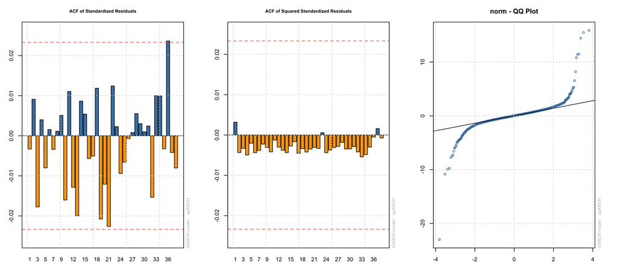

```r
spec_3b = ugarchspec(variance.model=list(model="apARCH", garchOrder=c(1,1)),
                     mean.model=list(armaOrder=c(1,1), include.mean=T,
                                     external.regressors=as.matrix(x)))
fit_3b = ugarchfit(data=y, spec=spec_3b, solver = 'nloptr')
show(fit_3b)
par(mfrow=c(1,3));par(mar=c(3,3,3,3))
plot(fit_3b,which=10)
plot(fit_3b,which=11)
plot(fit_3b,which=9)
```

If we re-fit the ARMAX(1,1) + APARCH(1,1) model with student-t distribution, the mean equation will not be adequate.

For this reason, we fix the coefficients of the mean equation to be equal to the estimated values with ARMAX(1,1) + APARCH(1,1) with normal error. We then estimate the APARCH(1,1) mode. The model is adequate and the QQ plots are a better fit than the normal plot.

```
*---------------------------------*
*          GARCH Model Fit        *
*---------------------------------*

Conditional Variance Dynamics
-----------------------------------
GARCH Model	: apARCH(1,1)
Mean Model	: ARFIMA(1,0,1)
Distribution	: std

Optimal Parameters
------------------------------------
        Estimate  Std. Error   t value Pr(>|t|)
mu      0.000005    0.000002  2.605180 0.009183
ar1     0.857964          NA        NA       NA
ma1    -0.790414          NA        NA       NA
mxreg1  0.231854          NA        NA       NA
omega   0.000000    0.000000  0.000853 0.999319
alpha1  0.053830    0.012106  4.446649 0.000009
beta1   0.859975    0.039132 21.976205 0.000000
gamma1 -0.071462    0.046801 -1.526929 0.126779
delta   2.326719    0.036378 63.959744 0.000000
shape   3.875600    0.167651 23.117136 0.000000

Robust Standard Errors:
        Estimate  Std. Error   t value Pr(>|t|)
mu      0.000005     0.00025  0.021552  0.98281
ar1     0.857964          NA        NA       NA
ma1    -0.790414          NA        NA       NA
mxreg1  0.231854          NA        NA       NA
omega   0.000000     0.00061  0.000000  1.00000
alpha1  0.053830    93.69601  0.000575  0.99954
beta1   0.859975   258.82307  0.003323  0.99735
gamma1 -0.071462    62.28057 -0.001147  0.99908
delta   2.326719   237.79196  0.009785  0.99219
shape   3.875600   263.48959  0.014709  0.98826

LogLikelihood : 52805.56

Information Criteria
```

[output cut: 51 more lines]

```
Negative Sign Bias  1.8437 0.06526   *
Positive Sign Bias  0.5343 0.59312
Joint Effect        4.5482 0.20803


Adjusted Pearson Goodness-of-Fit Test:
------------------------------------
  group statistic p-value(g-1)
1    20     35.94      0.01074
2    30     35.88      0.17697
3    40     52.32      0.07527
4    50     66.06      0.05240


Elapsed time : 7.937159
```

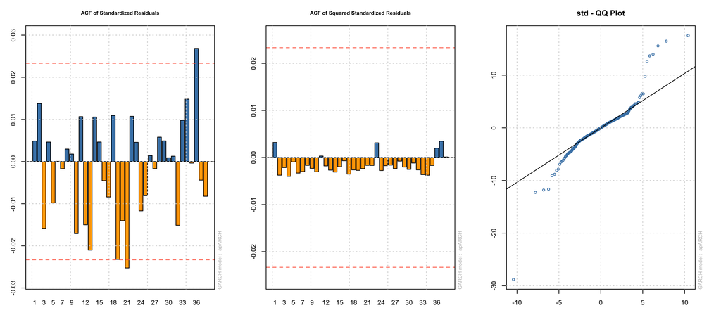

```r
spec_3b = ugarchspec(variance.model=list(model="apARCH", garchOrder=c(1,1)),
                     mean.model=list(armaOrder=c(1,1), include.mean=T,
                                     external.regressors=as.matrix(x)),
                     distribution.model="std",
                     fixed.pars = list(mxreg1=0.231854, ar1=0.857964 , ma1=-0.790414))
fit_3b = ugarchfit(data=y, spec=spec_3b, solver = 'nloptr')
show(fit_3b)
par(mfrow=c(1,3));par(mar=c(3,3,3,3))
plot(fit_3b,which=10)
plot(fit_3b,which=11)
plot(fit_3b,which=9)
```

Finally, based the leverage parameter, `gamma1`, is not significant (p-value 12.68%). So, there is no leverage effect.

# 3.

(7 points) Consider two NYSE traded stocks Billiton Ltd. (BHP) and Vale S.A. of Brazil (VALE). The daily adjusted closing price of the stocks, from July 2002 to March 2006, are included in the text file "HW6-Q3.txt" and can be accessed with the following code

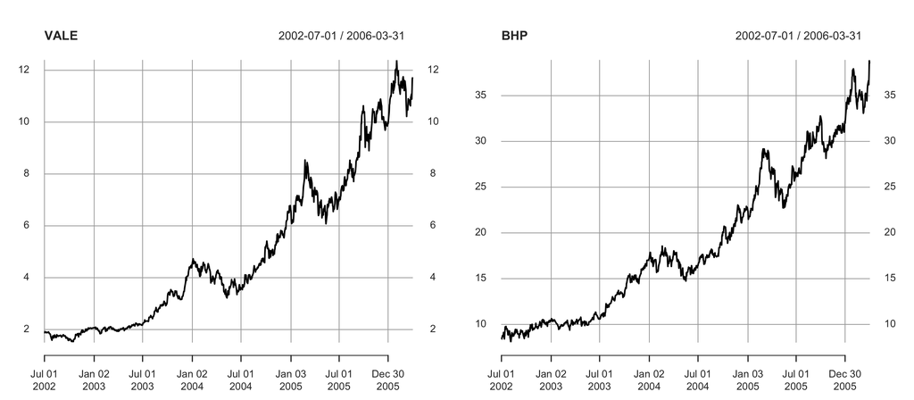

```r
dat=read.table("HW6-Q3.txt", header=TRUE, sep = ",")
VALE=xts(dat[,2], order.by=as.Date(dat[, 1]))
BHP=xts(dat[,3], order.by=as.Date(dat[, 1]))
names(VALE) = c("VALE");names(BHP) = c("BHP")
par(mfrow=c(1,2));par(mar=c(3,3,3,3))
plot(VALE)
plot(BHP)
```

Let $\{p_{1,t}\}$ and $\{p_{2,t}\}$ be the daily log-prices of BHP and VALE, respectively.

## (a)

(2 points) Determine the integration order of the log prices.

**Solution:** For $p_1=\log(BHP)$, the unit root tests disagree on whether the log prices are stationary or not (ADF and PP indicate stationary, while KPSS indicate unit root). For $p_2=\log(VALE)$, the unit root test indicate non-stationary under 5%. Under 5% significance level, the three test indicated that the log returns of both time series are stationary. So, integration order of both log prices is 1.

```r
p1=log(BHP)
p2=log(VALE)
rtn1 = na.omit(diff(p1))
rtn2 = na.omit(diff(p2))
adf.test(p1)
pp.test(p1)
kpss.test(p1)
adf.test(p2)
pp.test(p2)
kpss.test(p2)
```

```
	Augmented Dickey-Fuller Test

data:  p1
Dickey-Fuller = -3.4971, Lag order = 9, p-value = 0.04258
alternative hypothesis: stationary
```

```
	Phillips-Perron Unit Root Test

data:  p1
Dickey-Fuller Z(alpha) = -27.006, Truncation lag parameter = 7, p-value
= 0.01694
alternative hypothesis: stationary
```

```
	KPSS Test for Level Stationarity

data:  p1
KPSS Level = 11.695, Truncation lag parameter = 7, p-value = 0.01
```

```
	Augmented Dickey-Fuller Test

data:  p2
Dickey-Fuller = -3.263, Lag order = 9, p-value = 0.07705
alternative hypothesis: stationary
```

```
	Phillips-Perron Unit Root Test

data:  p2
Dickey-Fuller Z(alpha) = -21.266, Truncation lag parameter = 7, p-value
= 0.05346
alternative hypothesis: stationary
```

```
	KPSS Test for Level Stationarity

data:  p2
KPSS Level = 11.582, Truncation lag parameter = 7, p-value = 0.01
```

```r
adf.test(rtn1)
pp.test(rtn1)
kpss.test(rtn1)
adf.test(rtn2)
pp.test(rtn2)
kpss.test(rtn2)
```

```
	Augmented Dickey-Fuller Test

data:  rtn1
Dickey-Fuller = -10.829, Lag order = 9, p-value = 0.01
alternative hypothesis: stationary
```

```
	Phillips-Perron Unit Root Test

data:  rtn1
Dickey-Fuller Z(alpha) = -954.73, Truncation lag parameter = 7, p-value
= 0.01
alternative hypothesis: stationary
```

```
	KPSS Test for Level Stationarity

data:  rtn1
KPSS Level = 0.028274, Truncation lag parameter = 7, p-value = 0.1
```

```
	Augmented Dickey-Fuller Test

data:  rtn2
Dickey-Fuller = -9.9034, Lag order = 9, p-value = 0.01
alternative hypothesis: stationary
```

```
	Phillips-Perron Unit Root Test

data:  rtn2
Dickey-Fuller Z(alpha) = -824.43, Truncation lag parameter = 7, p-value
= 0.01
alternative hypothesis: stationary
```

```
	KPSS Test for Level Stationarity

data:  rtn2
KPSS Level = 0.070393, Truncation lag parameter = 7, p-value = 0.1
```

## (b)

(3 points) Use the two-step method to determine if the log-prices are cointegrated. What is the cointegrating relationship? Denote the cointegrating relationship by $\{z_t\}$.

**Solution:** We can conduct the two step procedure by `ca.po()` function. Alternatively, we can use the `po.test()` function and find the cointegrating relationship by regressing one time series on the other. The results will be the same. We use the `ca.po()` function here. The Phillips-Ouliaris test statistic is 113.488 which is larger than its 1% critical value of 48.0021. So, we accept that the log-prices are cointegrated. The fitted regression is

\begin{align*} p_{1,t} = 1.822648 + 0.716664\,p_{2,t} + z_t \end{align*}

Therefore, the cointegrating relationship is,

\begin{align*} z_t = p_{1,t} - 0.716664\,p_{2,t} - 1.822648. \end{align*}

```r
coint_po = ca.po(cbind(p1,p2), demean = "constant")
summary(coint_po)
```

```
########################################
# Phillips and Ouliaris Unit Root Test #
########################################

Test of type Pu
detrending of series with constant only


Call:
lm(formula = z[, 1] ~ z[, -1])

Residuals:
      Min        1Q    Median        3Q       Max
-0.151818 -0.028265  0.003121  0.029803  0.147105

Coefficients:
            Estimate Std. Error t value Pr(>|t|)
(Intercept) 1.822648   0.003662   497.7   <2e-16 ***
z[, -1]     0.716664   0.002354   304.4   <2e-16 ***
---
Signif. codes:  0 ‘***’ 0.001 ‘**’ 0.01 ‘*’ 0.05 ‘.’ 0.1 ‘ ’ 1

Residual standard error: 0.04421 on 944 degrees of freedom
Multiple R-squared:  0.9899,	Adjusted R-squared:  0.9899
F-statistic: 9.266e+04 on 1 and 944 DF,  p-value: < 2.2e-16


Value of test-statistic is: 113.488

Critical values of Pu are:
                  10pct   5pct    1pct
critical values 27.8536 33.713 48.0021
```

## (c)

(2 points) What is the mean of $\{z_t\}$? What is the standard deviation of $\{z_t\}$?

**Solution:** The mean of $\{z_t\}$ is 0, the standard deviation of $\{z_t\}$ is $0.04421$ (the residual standard error in the regression summary table).

**Remark:** If you did not include the constant term 1.822648 in your cointegrating relationship, then the mean of $\{z_t\}$ is 1.822648.

# 4

## (a) (2 points)

Consider the following error correction model:

\begin{align*} \Del\,\Yv_t = \alv\,\betav^\top\,\Yv_{t-1} + \epsv_t,\quad \{\epsv_t\}\sim\text{ weak WN} \end{align*}

where $\{\Yv_t\}$ are the observations, while $\alv$ and $\betav$ are unknown matrices of parameters to estimated. Can $\alv$ and $\betav$ be uniquely estimated from the observations of $\{\Yv_t\}$? Explain.

**Solution:** There is a parameter identification issue. Let A be any invertible matrix. Then, $\alv\,\betav^\top = \alv\,A\,A^{-1}\,\betav^\top = (\alv\,A)(\betav\,A^{-1\top})^\top$. Therefore, the pairs $(\alv, \betav)$ and $(\alv\,A, \betav\,A^{-1\top})$ both generate the same observations $\{\Yv_t\}$. In other words, knowing only $\{Y_t\}$, we cannot distinguish between the two pairs. So, $\alv$ and $\betav$ cannot be uniquely identified.

Consider 6 stocks with symbols GM, F, UTX, CAT, MRK, and PFE. Their daily adjusted closing prices are included in the text file "HW6-Q4.csv" and can be accessed with the following R code

```r
Stock_FX_Bond = read.csv("HW6-Q4.csv", header=T)
adjClose = Stock_FX_Bond[,seq(from=3, to=13, by=2)]
```

Answer part (b), (c), (d) and (e) below by \textbf{only} using the output of the following code.

```r
library(urca)
summary(ca.jo(adjClose))
```

```
######################
# Johansen-Procedure #
######################

Test type: maximal eigenvalue statistic (lambda max) , with linear trend

Eigenvalues (lambda):
[1] 0.0084547692 0.0072564690 0.0051633205 0.0025776931 0.0008369729
[6] 0.0001442690

Values of teststatistic and critical values of test:

          test 10pct  5pct  1pct
r <= 5 |  0.72  6.50  8.18 11.65
r <= 4 |  4.15 12.91 14.90 19.19
r <= 3 | 12.80 18.90 21.07 25.75
r <= 2 | 25.68 24.78 27.14 32.14
r <= 1 | 36.13 30.84 33.32 38.78
r = 0  | 42.12 36.25 39.43 44.59

Eigenvectors, normalised to first column:
(These are the cointegration relations)

            GM_AC.l2    F_AC.l2   UTX_AC.l2   CAT_AC.l2  MRK_AC.l2  PFE_AC.l2
GM_AC.l2    1.000000  1.0000000  1.00000000  1.00000000  1.0000000  1.0000000
F_AC.l2     4.531416 -0.9551802 -0.28799232 -4.24747632  1.7119472 -3.2445013
UTX_AC.l2  10.153184 -1.0428345  0.08234314  0.64915092 -1.2347453 -0.4338528
CAT_AC.l2  -6.277985  0.8757911 -0.15129166 -0.87993867  3.0277651  2.0114823
MRK_AC.l2   3.486062  0.5964530 -1.21531463  0.77098937  1.6299450  0.2413601
PFE_AC.l2 -12.690810 -0.8737509  0.97153655  0.07894025 -0.9841646 -1.3716608

Weights W:
(This is the loading matrix)

              GM_AC.l2       F_AC.l2     UTX_AC.l2     CAT_AC.l2     MRK_AC.l2
GM_AC.d  -3.969022e-04 -0.0010202560 -0.0058233366 -0.0011535050 -8.318635e-05
F_AC.d   -3.698444e-04  0.0005921880 -0.0015370569  0.0004423459 -6.840323e-05
UTX_AC.d -6.099495e-04 -0.0002158992 -0.0017197122 -0.0002484548  1.158356e-04
CAT_AC.d  9.366375e-05 -0.0038863917 -0.0019428948  0.0005983367  1.657404e-05
MRK_AC.d -1.119518e-04 -0.0005841174  0.0003775414 -0.0015259995 -1.677028e-04
PFE_AC.d  5.935071e-04  0.0021399235 -0.0015829569 -0.0003521045 -1.608370e-05
             PFE_AC.l2
GM_AC.d  -3.230871e-05
F_AC.d    2.875108e-05
UTX_AC.d  1.081514e-04
CAT_AC.d  9.385713e-05
MRK_AC.d  2.121552e-04
PFE_AC.d  1.402426e-04
```

## (b) (2 points)

Are the closing prices stationary?

**Solution:** We can perform a joint stationarity test by looking at the top row of the table of test statistics. Since $r\le 5$ is accepted, then not all the time series are stationary.

**Remark:** The top row of the Johansen test is equivalent to the following test: $H_0:$ at least one of the time series is non-stationary, versus $H_a:$ **all** of the times series are stationary. If $r\le (n-1)$ is accepted, we only know that some of the time series are non-stationary. If $r\le (n-1)$ is rejected, we know that **all** of the time series are stationary.

## (c)(2 points)

How many cointegrating relationships exist among the stocks? Use 5\% significance level, and explain your answer.

**Solution:** The test $H_0: r=0$ rejects the null hypothesis (teststatistic value of 42.12 is greater than the 5\% critical value of 39.43).

The test $H_0: r\le 1$ rejects the null hypothesis (teststatistic value of 36.13 is greater than the 5\% critical value of 33.32).

The test $H_0: r\le 2$ accepts the null hypothesis (teststatistic value of 25.68 is less than the 5\% critical value of 27.14).

Therefore, $r=2$. There are 2 cointegrating relationships.

## (d) (2 points)

Write down the fitted error correction model.

**Solution:** Let $\Pv_t = (P_{1,t}, \dots, P_{6,t})^\top$ be the stock prices. Then,

\begin{align*} \Del \Pv_t = \begin{pmatrix} -3.969022\times10^{-04} & -0.0010202560\\ -3.698444\times10^{-04} & 0.0005921880\\ -6.099495\times10^{-04} & -0.0002158992\\ 9.366375\times10^{-05} & -0.0038863917\\ -1.119518\times10^{-04} & -0.0005841174\\ 5.935071\times10^{-04} & 0.0021399235 \end{pmatrix} \begin{pmatrix} 1.000000 & 1.0000000\\ 4.531416 & -0.9551802\\ 10.153184 & -1.0428345\\ -6.277985 & 0.8757911\\ 3.486062 & 0.5964530\\ -12.690810 & -0.8737509 \end{pmatrix}^\top \Pv_{t-1} + \eps_t. \end{align*}

## (e)

Suggest a trading strategy based on the cointegration analysis.

**Solution:** Let $Z_{t,1}$ and $Z_{t,2}$ be the cointegrating relations:

\begin{align*} Z_{t,i} = \beta(i)^\top \Pv_t;\quad i\in\{1,2\}, \end{align*}

where $\beta(1)$ and $\beta(2)$ are the cointegrating vectors, that is, the columns of the matrix \begin{align*} \begin{bmatrix} 1.000000 & 1.0000000\\ 4.531416 & -0.9551802\\ 10.153184 & -1.0428345\\ -6.277985 & 0.8757911\\ 3.486062 & 0.5964530\\ -12.690810 & -0.8737509 \end{bmatrix}. \end{align*}

Consider portfolio A1 that holds $\beta_j(1)$ shares of the j-th stock (i.e. 1 shares of GM, 4.53 shares of F, etc.). Similarly let A2 be the portfolio that holds $\beta_j(2)$ shares of the j-th stock. Here, negative values imply holding a short position.

A trading strategy based on cointegrating relationships is as follows. Since $Z_{t,i}$ is mean reverting around its stationary means $\mu_i$, we short A1 whenever $Z_{t,i}>\mu_i + \sig_i$ and take a long position in A1 whenever $Z_{t,i}<\mu_i - \sig_i$. Here, $\sig_i$ is the stationary standard deviation of $Z_{t,i}$.